# State Reliance on the Personal Motor Vehicle

Nathan Willis

- Introduction
- Cost to Individual
  - Cost of Transporation Dependent on State
    - Data Collection
    - Data Observation
    - Data Cleaning
    - Data Visualization
    - Data Manipulation
    - Data Analysis
- Implimentation
  - Promotion of Public Transportation
  - Invest in Active Transportation
  - Adopt Electric Vehicles (EVs)
- Conclusion
- Sources

# Introduction

Within the US, the reliance on the motor vehicle and its alignment with the classic "American Dream" has had undeniable ramifications on US cities and transportation infrastructure have been developed upon as well as the individuals that live within these cities. With this analysis, the intention is to dive deeper into the cost transportation has to an individual aswell as to the public at large using a handfull of algorithm's that we have been taught over the semester including decision trees to determine what states should be of target when providing a solution to the over saturation of personal motor vehicles within the US.

# Cost to Individual

## Cost of Transportation Dependent on State

Using the cost of living index from state to state we can determine how much of the average individuals salary goes towards transporation and from this determine the weight that transportation has on an individual from specific states helping us target what states could use an improvement to transportation costs.

### Data Collection

This dataset was pulled from 'World Population Review' in csv format. This dataset is a collection of weigted indexes that describe the cost of living within a state for the year of 2023. This dataset includes the living index, the grocery cost index, the housing cost index, the misc cost index, the transportation cost index, and the utility cost index. The average of each of these indexes, listed on the 'World Population Review', is equivalant to a 100 within the indexed dataset.

### Data Observation

```python
# Directory Redirection
import os

print(os.getcwd())
os.chdir(r'C:/Users/17202/Desktop/DSC-3334-01-Algorithms&DataStructures/Datasets/Walkability Project')
print(os.getcwd())
```

```
C:\Users\17202\Desktop\DSC-3334-01-Algorithms&DataStructures\Notebooks
C:\Users\17202\Desktop\DSC-3334-01-Algorithms&DataStructures\Datasets\Walkability Project
```

```python
# Data Loading and Processing
import numpy as np
import pandas as pd

#configuration of pandas
pd.set_option('display.max_rows', None)
pd.set_option('display.max_columns', None)

#COLI == Cost Of Living Index
COLI = pd.read_csv('cost-of-living-index-by-state-2024.csv')

COLI.head()
```

|  | state | CostOfLivingIndex2023 | CostOfLivingIndexGroceryCostsIndex | CostOfLivingIndexHealthCostsIndex | CostOfLivingIndexHousingCostsIndex | CostOfLivingIndexMiscCostsIndex | CostOfLivingIndexTransportationCostsIndex | CostOfLivingIndexUtilityCostsIndex |
| --- | --- | --- | --- | --- | --- | --- | --- | --- |
| 0 | Alabama | 88.8 | 96.4 | 86.9 | 70.4 | 96.2 | 92.0 | 103.6 |
| 1 | Alaska | 124.4 | 127.4 | 149.8 | 118.1 | 118.8 | 121.9 | 148.1 |
| 2 | Arizona | 107.2 | 101.8 | 93.5 | 125.3 | 102.1 | 99.2 | 94.3 |
| 3 | Arkansas | 90.3 | 95.4 | 87.2 | 76.3 | 99.1 | 92.2 | 91.8 |
| 4 | California | 134.5 | 112.3 | 106.4 | 186.5 | 110.9 | 124.1 | 124.8 |

```python
COLI.tail()
```

|  | state | CostOfLivingIndex2023 | CostOfLivingIndexGroceryCostsIndex | CostOfLivingIndexHealthCostsIndex | CostOfLivingIndexHousingCostsIndex | CostOfLivingIndexMiscCostsIndex | CostOfLivingIndexTransportationCostsIndex | CostOfLivingIndexUtilityCostsIndex |
| --- | --- | --- | --- | --- | --- | --- | --- | --- |
| 47 | Washington | 115.1 | 109.700000 | 119.800000 | 129.40000 | 110.800000 | 117.100000 | 92.200000 |
| 48 | West Virginia | 90.3 | 97.700000 | 97.000000 | 70.90000 | 99.000000 | 97.800000 | 94.500000 |
| 49 | Wisconsin | 95.0 | 97.900000 | 113.700000 | 84.40000 | 96.700000 | 98.600000 | 102.800000 |
| 50 | Wyoming | 92.8 | 102.000000 | 98.600000 | 80.70000 | 99.000000 | 95.600000 | 85.700000 |
| 51 | United States | NaN | 101.215686 | 101.139216 | 109.04902 | 102.476471 | 102.611765 | 101.741176 |

```python
COLI.info(verbose = False)
```

```
<class 'pandas.core.frame.DataFrame'>
RangeIndex: 52 entries, 0 to 51
Columns: 8 entries, state to CostOfLivingIndexUtilityCostsIndex
dtypes: float64(7), object(1)
memory usage: 3.4+ KB
```

Our data set contains 52 rows of data and 8 columns of data

```python
COLI.dtypes
```

```
state                                         object
CostOfLivingIndex2023                        float64
CostOfLivingIndexGroceryCostsIndex           float64
CostOfLivingIndexHealthCostsIndex            float64
CostOfLivingIndexHousingCostsIndex           float64
CostOfLivingIndexMiscCostsIndex              float64
CostOfLivingIndexTransportationCostsIndex    float64
CostOfLivingIndexUtilityCostsIndex           float64
dtype: object
```

Columns:

- `state` - the state (object)
- `CostOfLivingIndex2023` - The Indexed Cost of Living (float64)
- `CostOfLivingIndexGroceryCostsIndex` - The Indexed Cost of Groceries (float64)
- `CostOfLivingIndexHealthCostsIndex` - The Indexed Cost of Health (float64)
- `CostOfLivingIndexHousingCostsIndex` - The Indexed Cost of Housing (float64)
- `CostOfLivingIndexMiscCostsIndex` - The Indexed Cost of Miscellaneous Purchases (float64)
- `CostOfLivingIndexTransportationCostsIndex` - The Indexed Cost of Transportation (float64)
- `CostOfLivingIndexUtilityCostsIndex` - The Indexed Cost of Utility (float64)

For this analysis, I think its safe to deem the other variables inconsequential to providing us with our final insight of the American Reliance on the motor vehicle. `state` being our independent variable, I believe the only dependent variables that could play a part on the American Reliance on the motor vehicle are the `CostOfLivingIndex2023` and the `CostOfLivingIndexTransportationCostsIndex`.

### Data Cleaning

```python
COLI = COLI[['state', 'CostOfLivingIndex2023','CostOfLivingIndexTransportationCostsIndex']]

COLI.columns = COLI.columns.str.replace('Index', '')

toRepl = COLI.columns.values[1:3]
repl = ['living', 'transportation']

for x in range(len(toRepl)):
    COLI.columns = COLI.columns.str.replace(toRepl[x], repl[x])

COLI.head()
```

|  | state | living | transportation |
| --- | --- | --- | --- |
| 0 | Alabama | 88.8 | 92.0 |
| 1 | Alaska | 124.4 | 121.9 |
| 2 | Arizona | 107.2 | 99.2 |
| 3 | Arkansas | 90.3 | 92.2 |
| 4 | California | 134.5 | 124.1 |

Im going to drop the final row where `state` == 'United states' as the total is non-applicable.

```python
COLI = COLI.drop(51)
COLI.tail()
```

|  | state | living | transportation |
| --- | --- | --- | --- |
| 46 | Virginia | 103.1 | 96.5 |
| 47 | Washington | 115.1 | 117.1 |
| 48 | West Virginia | 90.3 | 97.8 |
| 49 | Wisconsin | 95.0 | 98.6 |
| 50 | Wyoming | 92.8 | 95.6 |

Now Im going to convert state values to their state abbreviations using an outside csv that list state names and their equivalent abreviations.

(CSV pulled from github, found under Sources)

```python
stateAbbrev = pd.read_csv('states.csv')
stateAbbrev.head()
```

|  | State | Abbreviation |
| --- | --- | --- |
| 0 | Alabama | AL |
| 1 | Alaska | AK |
| 2 | Arizona | AZ |
| 3 | Arkansas | AR |
| 4 | California | CA |

```python
COLI['state'] = stateAbbrev['Abbreviation']

COLI.head()
```

|  | state | living | transportation |
| --- | --- | --- | --- |
| 0 | AL | 88.8 | 92.0 |
| 1 | AK | 124.4 | 121.9 |
| 2 | AZ | 107.2 | 99.2 |
| 3 | AR | 90.3 | 92.2 |
| 4 | CA | 134.5 | 124.1 |

```python
COLI.tail()
```

|  | state | living | transportation |
| --- | --- | --- | --- |
| 46 | VA | 103.1 | 96.5 |
| 47 | WA | 115.1 | 117.1 |
| 48 | WV | 90.3 | 97.8 |
| 49 | WI | 95.0 | 98.6 |
| 50 | WY | 92.8 | 95.6 |

This dataset is an index dataset, meaning that it uses a baseline value that is to be compared to the full dataframe of index values. In my analysis I intend to convert these values from indexed to their proper dollar amounts.

- The index value, where `living` is equivalent to 100 within the `living` column is equivalent to $61,334 otherwise known as the average cost of `living` within the `state` specified for a single year. (worldpopulationreview.com)
- The ikndex value, where `transportation` is equivalent to 100 within the `transportation` column is equivalent to $9813.44 otherwise known as the average cost of `transportation` within the `state` specified for a single year. This is equivalent to 16% of the full `living` cost. (worldpopulationreview.com)

This implies that, on average, a United States citizen spends 16% of their yearly income exclusively on `transportation`. This value most likely changes from state to state dependent on the cost of `living` within that state and the infrastructure provided by the state in the area of living. Now I'm going to convert the index values to their monetary equivalents.

```python
#COLM - Cost Of Living Monetarily
COLM = COLI.copy()

npLiv = COLI['living'].to_numpy()
npLivMon = ((npLiv / 100) * 61334)
COLM['living'] = npLivMon

npTranspo =  COLI['transportation'].to_numpy()
npTranspoMon = ((npTranspo / 100) * 9813.44)
COLM['transportation'] = npTranspoMon

COLM = COLM.round({'living':2, 'transportation': 2})

COLM.head()
```

|  | state | living | transportation |
| --- | --- | --- | --- |
| 0 | AL | 54464.59 | 9028.36 |
| 1 | AK | 76299.50 | 11962.58 |
| 2 | AZ | 65750.05 | 9734.93 |
| 3 | AR | 55384.60 | 9047.99 |
| 4 | CA | 82494.23 | 12178.48 |

After the creation of the monetary dataframe we can compute the percentage value's for the comparison of the average citizens cost of living within that state to the average citizens transportation cost within that state. This information can help us pinpoint what states could use an improvement in walkable infrastructure, to reduce the amount of income used torwards transportation within that specific state.

```python
npAvg = (npTranspoMon / (npLivMon / 100))
COLI['livingToTransportation'] = npAvg.tolist()

COLI = COLI.sort_values(by = ['livingToTransportation'], ascending = False)
COLI.head()
```

|  | state | living | transportation | livingToTransportation |
| --- | --- | --- | --- | --- |
| 28 | ND | 101.3 | 117.2 | 18.511352 |
| 27 | NC | 90.1 | 101.8 | 18.077691 |
| 13 | IL | 90.8 | 102.4 | 18.044053 |
| 15 | IA | 89.7 | 100.6 | 17.944259 |
| 38 | PA | 99.0 | 108.2 | 17.486869 |

After pulling the head of the reformed `COLI` dataframe that has been resorted based on the `livingToTransportation` column we can infer that the states of:

- `ND` = North Dakota
- `NC` = North Carolina
- `IL` = Illinois
- `IA` = Iowa
- `PA` = Pennsylvania

could use a reformation to their current transportation infrastructure as far as walkability and available public transportation is concerned in order to reduce the current costs of transportation for their citizens, and the American reliance on the personal motor vehicle (PMV). Futhermore we can determine the number of states that fall above the United States citizen's average spending on Transportation (16%) in order to determine what states may be of concern when improving walkable infrastructure, public transportation, and reducing the American reliance on the PMV.

```python
COLITranspoAboveAvg = COLI[(COLI['livingToTransportation'] > 16)]
COLITranspoAboveAvg['livingToTransportation'].count()
```

```
28
```

28 states fall above the United States citizen's average spending on Transportation (16%) which is more than half of the United States.

Those 28 states are:

```python
COLITranspoAboveAvg['state']
```

```
28    ND
27    NC
13    IL
15    IA
38    PA
48    WV
36    MS
34    MI
7     DE
22    NV
18    LA
23    NH
14    IN
17    KY
35    MN
24    NJ
10    GA
49    WI
0     AL
12    ID
50    WY
25    NM
3     AR
5     CO
47    WA
19    ME
16    KS
45    VT
Name: state, dtype: object
```

### Data Visualization

```python
%matplotlib inline
import matplotlib.pyplot as plt
import matplotlib as mpl
import seaborn as sns
from sklearn.linear_model import LinearRegression

sns.set(style = 'darkgrid')
```

Below is a visualization of the Living Index value compared to Transportation compared to Living Percentage.

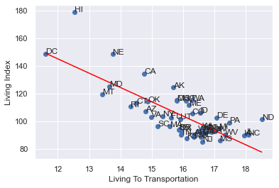

```python
fig, ax = plt.subplots()

ax.scatter(COLI['livingToTransportation'], COLI['living'])
ax.set_xlabel('Living To Transportation')
ax.set_ylabel('Living Index')

X = COLI.iloc[:, 3].values.reshape(-1, 1)
Y = COLI.iloc[:, 1].values.reshape(-1, 1)
linear_regressor = LinearRegression()
linear_regressor.fit(X, Y)
Y_pred = linear_regressor.predict(X)

plt.plot(X, Y_pred, color='red')

for k, v in COLI.iterrows():
    ax.annotate(v['state'], (v['livingToTransportation'],v['living']))
```

We can gather that there is a linear pattern, where as the living index declines, the cost of transportation increases. This implies that Transportation is a greater amount of the yearly income in lower living cost index states.

### Data Manipulation

Creating a Decision tree to decide what parameters states should have to be considered states of focus in improving the transportation index

```python
# Initiation of Libraries
from sklearn.model_selection import train_test_split
from sklearn.ensemble import RandomForestRegressor
from sklearn.tree import export_graphviz
import pydot
```

```python
lab = np.array(COLI['livingToTransportation'])

feat = COLI.drop(['state','livingToTransportation'], axis = 1)

feat_list = list(feat.columns)
feat = np.array(feat)
```

```python
train_feat, test_feat, train_lab, test_lab = train_test_split(
    feat, lab, test_size = 0.25, random_state = 0)
```

```python
# Instantiate model with 1000 decision trees
rf = RandomForestRegressor(n_estimators = 1000, random_state = 0)

# Train the model on training data
rf.fit(train_feat, train_lab);
```

```python
# Use the forest's predict method on the test data
predictions = rf.predict(test_feat)

# Calculate the absolute errors
errors = abs(predictions - test_lab)
print('Mean Absolute Error:', round(np.mean(errors), 2))
```

```
Mean Absolute Error: 0.36
```

```python
# Pull out one tree from the forest
tree = rf.estimators_[999]
```

```python
#Directory redirection
print(os.getcwd())
os.chdir(r'C:/Users/17202/Desktop/DSC-3334-01-Algorithms&DataStructures/Trees')
print(os.getcwd())
```

```
C:\Users\17202\Desktop\DSC-3334-01-Algorithms&DataStructures\Datasets\Walkability Project
C:\Users\17202\Desktop\DSC-3334-01-Algorithms&DataStructures\Trees
```

```python
# Export the image to a dot file
export_graphviz(tree, out_file = 'COLI.dot',
                feature_names  = feat_list,
                rounded        = True,
                precision      = 1)

# Use dot file to create a graph
graph = pydot.graph_from_dot_file('COLI.dot')

# Write graph to a png file
graph.write_png('COLI.png')
```

```
True
```

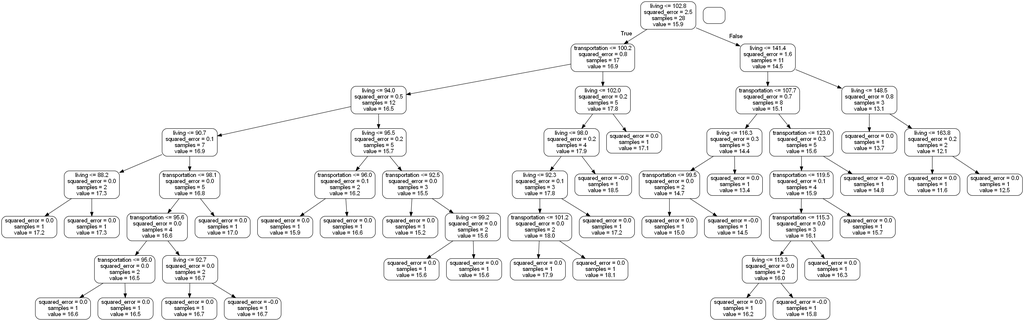

```python
# Limit depth of tree to 5 levels
small = RandomForestRegressor(n_estimators=1000,
                                 max_depth = 3,
                                 random_state = 0)
small.fit(train_feat, train_lab)

# Extract the small tree
small_tree = small.estimators_[999]

# Export the image to a dot file
export_graphviz(small_tree, out_file = 'COLIshort.dot',
                feature_names  = feat_list,
                rounded        = True,
                precision      = 1)

# Use dot file to create a graph
graph = pydot.graph_from_dot_file('COLIshort.dot')

# Write graph to a png file
graph.write_png('COLIshort.png')
```

```
True
```

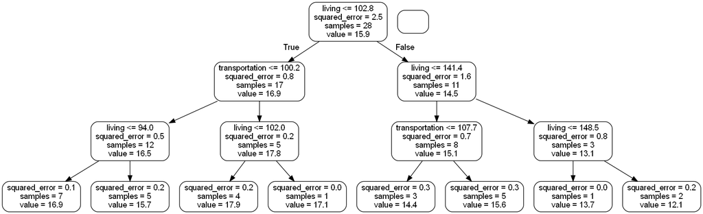

### Data Analysis

With our decision tree we can conclude that out of the 28 states sampled for the tree, and out of all states, we will find that states with a lower living index are more in need of reformation to transportation. This pattern of behavior was recognized in the linear regression model from earlier solidifying the belief that lower living indexes require some reformation to transportation. Avenues of reformation will be explore further within our implementation section.

## Implementation

Which will be expanded upon below

### Promotion of Public Transportation

Reducing the amount of vehicles would target the issue of over saturation signifigantly. A majority of households within the United States own at minimum one personal vehicle. Reducing the amount of vehicles on the roads and the cost of maitenance, gas, and insurance by reducing the number of vehicles is the objective. In order to do this we can promote the use of public transportation systems. It may be wise for the government to offer incentives to growing cities for public transportation systems. It also has personal benefits improving safety, health, and our focus, equity. (U.S. Department of Transportation)

[figure not shown]

### Invest in Active Transportation

Active Transportation is defined as transportation that does not require a personal motor vehicle, often by medium of walking, biking, scootering, or skating.(U.S. Department of Transportation) With a focus on infrastructure, cities can promote public transportation and focus on improving environments that focus on what people have available to them. Their own two feet. By using and creating more friendly walkable infrastructure that goes beyond the minimums a reduction of the personal motor vehicle is may be possible.

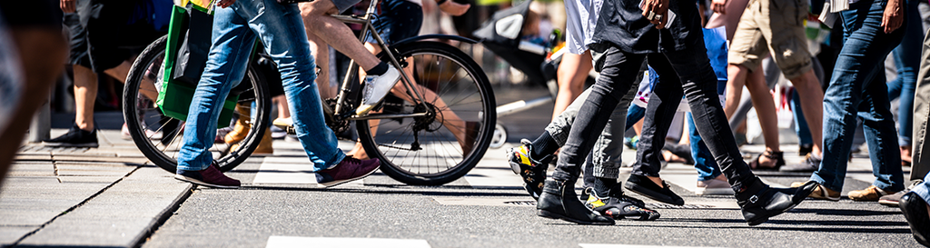

### Adopt Electric Vehicles (EVs)

For the individual electric vehicles can reduce the weight that fuel and maitenance plays on their own individual transportation index. By incentivizing the use of electric vehicles through the use of subsidies, tax credits, and charging station infrastructure we can reduce the weight the Personal Motor Vehicle has on the individuals transportation index.

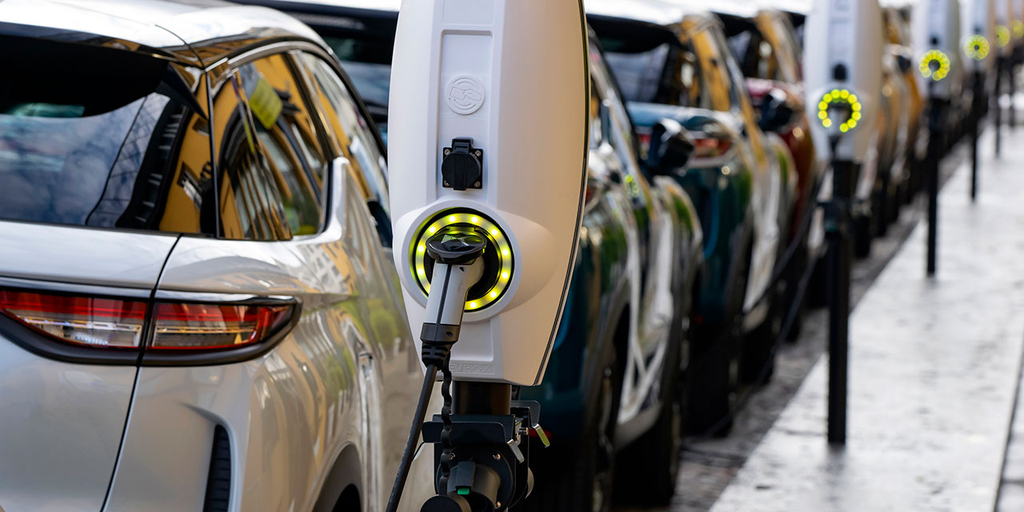

# Conclusion

The American Reliance on the motor vehicle and it's implications its had on its people is evident by the amount of money specifically used for transportation needs within the United States. Through the use of indexed data on living transportation, linear regression, and decision trees within this analysis it could be gathered what specific states could be of target for transportation reformation. The three Implementations are just a few of the many implementations that could be explored. In the future it may be of interest to look further into the avenues of reformation and looking into the expansion of Public Transportation, Active Transportation, and Electric Vehicles.

# Sources

- [Cost of Living Index by State 2024 (COLI)](https://worldpopulationreview.com/state-rankings/cost-of-living-index-by-state)
- [List-of-US-States](https://github.com/jasonong/List-of-US-States/blob/master/states.csv)
- [Expanding Public Transportation](https://www.transportation.gov/mission/health/Expand-Public-Transportation-Systems-and-Offer-Incentives)
- [Active Transportation](https://www.transportation.gov/mission/office-secretary/office-policy/active-transportation/active-transportation)